# ReLUPlex: An Efficient SMT Solver for Verifying Deep Neural Networks

Atharva Sehgal <atharvas@utexas.edu>

## Overview and Motivation

Neural networks are particularly opaque, and the lack of transparency in their decision-making process has led to a number of high-profile failures [2]. Yet, for many problems, neural networks offer significant advantages over their symbolic counterparts. Consecutively, the use of neural networks in software systems are only increasing. This makes it imperative to develop techniques to verify neural networks.

In the context of neural networks, verification entails proving that the output of a neural network is sound with respect to inputs within a pre-determined input range. This gives us two metrics we need to optimize: (1) the number of parameters of the neural network we are trying to verify and (2) the size of the domain of the neural network for which we are trying to find a certification. Verifying neural networks is usually NP complete in the size of the parameters and the input range we wish to certify. Hence, optimizing (1) and (2) together is out of the question. To this extent, there are two areas of research within trustworthy ML that differ in how they lower expectations. On the one hand, we have incomplete certification techniques that attempt to verify large neural networks for a fixed region around a finite number of elements in a dataset. These techniques treat soundness as an optimization problem and scale well to large neural networks. However, they are inexact, and the certified properties are extremely weak. On the other hand, we have complete verification techniques. These techniques treat soundness as a satisfiability problem and attempt to certify soundness for a large input range of a small neural network. ReLUPlex[4] belongs to the latter category of methods.

ReLUPlex’s main impact is that it was the first sufficiently scalable complete determinstic verification algorithm that found practical applications. Specifically, it was used to certify the robustness of an aircraft collision avoidance system. The rest of the sections will elucidate the underlying algorithms and tradeoffs that allowed ReLUPlex to scale to large neural networks. In the process, we will also touch upon how ReLUPlex fits into the model checking paradigm and whether the approach efficiently balances the assumptions it makes with respect to the problems it solves.

## Preliminaries

### Certification of Neural Networks

We are interested in certified verification of deep neural networks that are trained on a supervised dataset to classify high dimensional inputs. Formally, a neural network $f_\theta$ is a function parametrized by $\theta$ from a bounded $n$ dimensional input space, $\mathcal{X}$, to a space of the set of confidence scores for $C$ classes.

$$\begin{align*}
f_\theta : \mathcal{X} \rightarrow \mathbb{R}^C && x \in
\mathcal{X} \subseteq [0, 1]^n
\end{align*}$$

For data points $(x_0, y_0) \in (\mathcal{X} \times \mathcal{Y})$, neural network $f_{\theta}$, feasible input region $B_p^{\epsilon}(x_0)$, and a threshold $\epsilon$, A complete verification algorithm $\mathcal{A}(f_{\theta}, x_0, y_0, \epsilon)$ shows that:

$$\begin{align*}
\forall (x_0, y_0), \quad& \exists x \in
B_p^\epsilon(x_0)\quad\text{s.t} \quad f_\theta(x) \neq y_0 \\
\implies& \mathcal{A}(f_\theta, x_0, y_0, \epsilon) = \text{false}
\end{align*}$$

> 🚩 (Lowering Expectations) This definition provides a concrete formalism for the notion of *sufficient* soundness. Verifying soundness for a large input range is intractable; instead, we predetermine a feasible input region and attempt to derive certifications for said region. This can be thought of as an instantiation of lowering expectations.

A feedforward neural network is a specific instantiation of a neural network where the function $f_\theta$ is defined as:
$$\begin{align*}
f_\theta(x) &= \hat{z}_{(l)}\\
s.t.&\begin{cases}
z_{(1)} = x\\
\hat{z}_{({i+1})} = \mathbf{W}_iz_{(i)} + b_i & \forall i \in [1,
\dots l-1]\\
z_{({i})} = \sigma(\hat{z}_{(i)}) & \forall i \in [2, \dots l]
\end{cases}
\end{align*}$$

Within the class of feedforward neural networks, a ReLU network is a specific instantiation of a feedforward network where the nonlinear function $\sigma$ is $\text{ReLU}(z)$ defined as:
$$\text{ReLU}(x) = \max(0, x)$$

The ReLU non-linearity is a comparatively simple function to compute, easy to optimize, and scales well with the number of parameters. This makes ReLU networks popular in practice.

### Encoding ReLU networks as a satisfiability problem

ReLU networks also have the property that the output of a ReLU network is piecewise linear with respect to the input. The following figure shows a visualization[6] of the piecewise linearity of the decision boundaries of a 3 layer ReLU network.

Synthetic dataset

3 layer ReLU Net decision boundaries

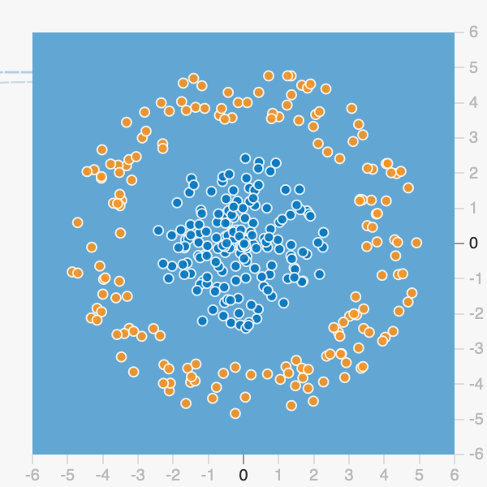

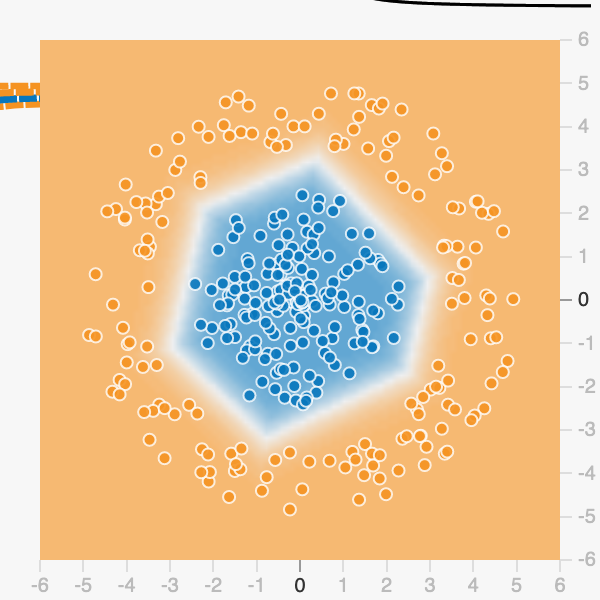

This piecewise linearity implies that a reasonable approach to encoding ReLU networks is to encode the ReLU node as a disjunction of linear constraints and the network as a conjunction of these disjunctions. This is the approach taken by ReLUPlex. Specifically,

- Each matrix multiplication can be encoded as a linear constraint:
  $$l(z_{(l)}, \hat{z}_{(l)} ) = \left( \hat{z}_{(l)} =
  \sum_{j=1}^{|z_{(l)}|} c_{j} \cdot z_{(l),j} + b \right)$$
- The ReLU activation function can be expressed as a disjunction of its input-output behavior:
  $$\text{ReLU}(\hat{z}_{(l)}, \tilde{z}_{(l)}) = \left( \hat{z}_{(l)} >
  0 \implies \tilde{z}_{(l)} = \hat{z}_{(l)} \right) \land \left(
  \hat{z}_{(l)} \leq 0 \implies \tilde{z}_{(l)} = 0 \right)$$
- The input to subsequent layers is the output of the previous layer:
  $$\begin{align*}
  \forall i \in [2, \dots l], \quad& z_{(i)} = \tilde{z}_{(i - 1)}\\
  \end{align*}$$
- Hence, for a given set of preconditions $\texttt{pre}$ and postconditions $\texttt{post}$, the verification of the ReLU network can be encoded as:
  $$\begin{align*}
  &{z}_{(1)} = x\\
  \land \forall i \in [1, \dots l], \quad& l(z_{(i)}, \hat{z}_{(i)}
  )\\
  \land \forall i \in [1, \dots l], \quad& \text{ReLU}(\hat{z}_{(i)},
  \tilde{z}_{(i)})\\
  \land \forall i \in [2, \dots l], \quad& z_{(i)} = \tilde{z}_{(i -
  1)}\\
  \land \quad& \hat{z}_{(l)} = y\\
  \land \quad&\texttt{pre}(x)\\
  \implies& \texttt{post}(y_0)
  \end{align*}$$

> 🚩 **Lowering Expectations** (Restricting to ReLU networks): ReLUPlex attempts to make a sufficiently scalable SMT verifier rescrited to the class of ReLU networks. This is a practical tradeoff because ReLU nets are popular in practice.

> ⚠️ **Pitfall**: (Give “scalability”, take away “expressiveness”) ReLUPlex attempts to make a sufficiently scalable ReLU net verifier but, in the process, it makes a number of assumptions that make it difficult to generalize to small purturbations in the architecture (eg: ReLU nets have been modified to include `LayerNorm` normallizations and `LeakyReLU` activations. ReLUPlex cannot handle these changes).

### A Naive Approach to verifying ReLU networks

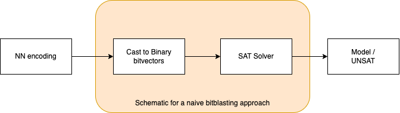

Now, a naive approach to finding a satisfying assignment to the above formula would be to encode the formula as a SAT problem and use a SAT solver to find a satisfying assignment. Assume we have $k$, $n$ dimensional integer vector. Casting these vectors to an $m$ bit binary representation should yield $O(kn \log(m))$ binary bitvectors. Now, Bitblasting each vector involves converting it into a circuit of AND, OR, and NOT gates, where each gate corresponds to a single bit operation. This is a very large SAT problem, and would be intractable to solve for large neural networks.

This approach fails because it disregards the structure of the problem. For instance, consider a set of linear constraint $x + y > 10 \land x - y > 10$. Interpreting this linear constraint in the LRA theory leads to the insight that the two constraints are describing the same variables. However, in the SAT encoding, we will treat each term independently, which destroys the structure of the linear inequalities.

To this extent, the authors of ReLUPlex pair the SAT solver with a dedicated *theory solver*. The *theory solver* interprets the linear constraints in the theory of Linear Real Arithmetic and attempts to find a satisfying assignment to the linear constraints or `UNSAT`. The SAT solver manages the boolean constraints: performing case splitting, boolean propagation, and conflict resolution when necessary.

The problem of solving numerous linear constraints is well studied in the linear programming literature, and there are many efficient algorithms for solving such problems. The authors choose to use the Simplex algorithm to solve the linear constraints.

> 🚩 **Exploiting Laziness** (Using SMT solvers instead of SAT solvers): Instead of eagerly trying to solve all possible constraints, ReLUPlex exploits the structure of the problem and divides the problem of verifying ReLU nets into the problem of selecting which constraints to verify and verifying those constraints using a theory suitable for linear inequalities.

### The Simplex Algorithm

Simplex is an algorithm for finding the optimal solution to a linear program. The basic idea of the simplex algorithm is to iteratively improve a feasible solution until an optimal solution is found. Instead of describing the Simplex algorithm in detail, we shall run through the simplex algorithm on a simple example to develop some intuition for how the algorithm works. Consider the following linear program (from [1]):

$$\begin{align*}
x + y \geq 0 \tag{constraint 0}\\
-2x + y \geq 2 \tag{constraint 1}\\
-10x + y \geq -4 \tag{constraint 2}\\
\end{align*}$$

> 🚩 **Exploiting Laziness** (Lazy constraint solving in Simplex): Simplex does not eagerly try to satisfy all the constraints. Instead, it locally satisfies constraints and iteratively improves the solution until all constraints are satisfied. This is a case of making the problem easier by relaxing the search space and then iteratively improving the solution.

> 🚩 **Exploiting Shallowness** (Eager evaluation of simplex): The simplex algorithm is designed to return the best solution to a linear program. However, ReLUPlex, instead, modifies the simplex algorithm to return the first solution to a linear program. This is because we are only interested in the existence of a solution to the linear program, not the best solution.

The Simplex algorithm runs in $O(2^n)$ worst case complexity, where $n$ is the number of linear constraints. On average, this worst case complexity is not reached.

### Another Naive Approach

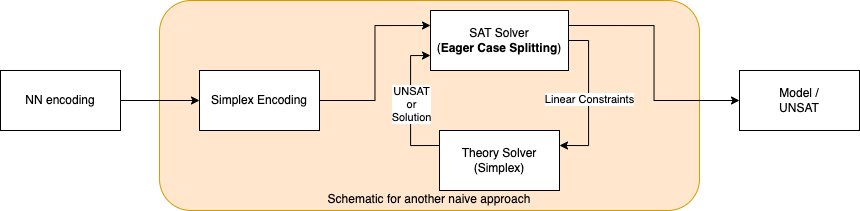

Given the simplex algorithm, we can propose a naive SMT solver based algorithm for verifying neural networks. Specifically, for a given ReLU network, we unroll all the constraints into CNF form and use Simplex to solve linear constraints and a SAT solver to handle the boolean constraints.

While this approach is more scalable than the first naive approach, it still has some issues. Specifically, the number of constraints grows exponentially with the number of nodes. This is because each ReLU node introduces two disjoint constraints. Hence, for a network with 400 ReLU nodes, we will need $2^{400}$ queries to Simplex if we want to reason about all cases. Since simplex, in the worst case, runs in $O(2^n)$ time, this problem is NP-complete and still intractable for large ReLU networks.

## ReLUPlex Algorithm

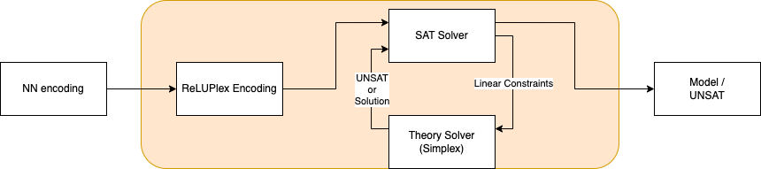

The ReLUPlex algorithm

The failure of the previous approaches to verify ReLU nets is due to the fact that they ignore the structure of the ReLU nodes by attempting to explicitly consider all possible case splits. While this approach guarantees termination, it is intractable for a large ReLU network. ReLUPlex attempts to relax the case splitting of ReLU nodes by natively handling ReLU constraints in addition to linear inequalities in the theory solver. So, instead of explicitly considering all possible case splits, ReLUPlex will only consider case splits when the theory solver fails to find a satisfying assignment (A fuel parameter $\tau$ bounds the number of time ReLUPlex loops over a certain ReLU node). To this extent, ReLUPlex extends the Simplex algorithm to handle ReLU constraints. Crucially, ReLUPlex allows the variables to temporarily violate the constraints while it looks for a feasible interpretation. This is similar to the Simplex algorithm. However, ReLUPlex makes additional optimizes to the Simplex algorithm to make it more suitable for verifying ReLU networks. However, handling ReLU constraints in the theory interpretation is not enough; and ReLUPlex can get stuck in a loop, at which point a case split is necessary. To this extent, ReLUPlex uses a bounding heuristic to determine when to perform a case split.

The full algorithm is presented below, after which I go through the salient points of the algorithm.

```lua
I ← an interpretation that sets all variables of F to 0
F` ← the non-ReLU constraints of F
while true do
    -- (1) simplex call
    r ← Simplex(F`, I)
    if r is UNSAT then return UNSAT
    if I satisfies F then return I
    if there exists a violated ReLU constraint xi = relu(xj) in I then
        -- (2) pivot basic variable
        if xi is basic-variable then
            pivot xi with non-basic variable xk, where k ≠ j and cik ≠ 0
        else if xj is basic-variable then
            pivot xj with non-basic variable xk, where k ≠ i and cjk ≠ 0
        -- (3) Update interpretation
        I(xi) ← relu(I(xj)) or I(xj) ← I(xi)
        if uj > 0 and lj < 0 and the number of times xi=relu(xj) is considered > τ then
            -- (4) case split
            r1 ← ReLUPlex(F ∧ xj > 0 ∧ xi = xj)
            r2 ← ReLUPlex(F ∧ xj ≠ 0 ∧ xi = 0)
            if r1 = r2 = UNSAT then return UNSAT
            if r1 ≠ UNSAT then return r1
            return r2
```

The general idea behind the algorithm is that we want to *delay* the case splitting to only when Simplex fails.

> 🚩 **Exploiting Laziness** (Incremental Case Splitting): ReLUPlex uses incremental case splitting to reduce the number of case splits it needs to consider. Specifically, it will only consider case splits when the theory solver fails to find a satisfying assignment.

Besides this, there are a couple of additional tricks that Simplex uses to scale up to handle large ReLU networks.

1. The pivot operations require multiplying and dividing the current bound till it satisfies the current constraint. In practice, ReLUPlex makes millions of pivot operations and the size of the numerators and denominators can blow up due to these operations. In this case, using arbitrary-precision rational numbers slows down the solver a lot. To manage this, ReLUPlex uses floating point approximations to keep track of the bounds and tracks the round-off error for each bound. If the round-off error exceeds a predetermined $\epsilon$ deviation from the starting bound, ReLUPlex restores the coefficients to the initial values and recomputes the pivots.

   > 🚩 **Apply Magic** (Inexact Floating Point Arithmetic): ReLUPlex models linear constraints using approximations of floating point constraints. This speeds up the pivot operatins.

   > 🚩 **Apply Magic** (Bound tightening): ReLUPlex unifies single variable linear constraints prior to calling the theory solver. This reduces the number of variables that the theory solver needs to consider and, furthermore, allows us to better inform SAT case splitting.

## Experimental results.

The authors test their algorithm to verify the ACAS XU aircraft avoidance system. The ACAS XU system consists of an array of 45 ReLU networks and fit in about 2MB of memory (which makes them very useful for aerospace applications). The general overview of the system is presented below. On a high level, the system consumes a set of variables and outputs an advisory from a finite class of potential advisories.

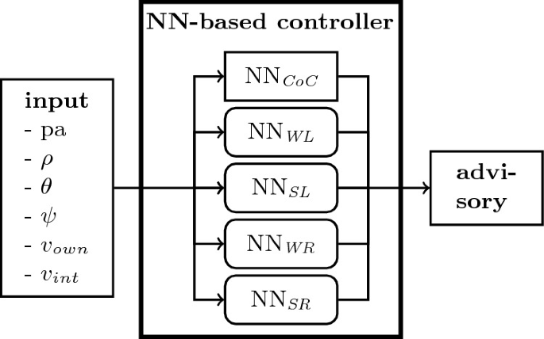

Overview of the ACAS XU System

The authors use ReLUPlex to verify the safety of the ACAS XU system. They compare the performance of ReLUPlex against five state of the art SMT solvers (Z3, CVC4, Yices, MathSAT, Gurobi) in three experimental domains,

1. The authors ran all the solvers with a 4 hour timeout on a randomly chosen ACAS Xu ReLU network. The goal was to check the satisfiability of eight simple properties $\varphi_1, \dots, \varphi_8$ that were chosen to be representative of the properties that the ACAS Xu system is expected to satisfy. The results are presented below.

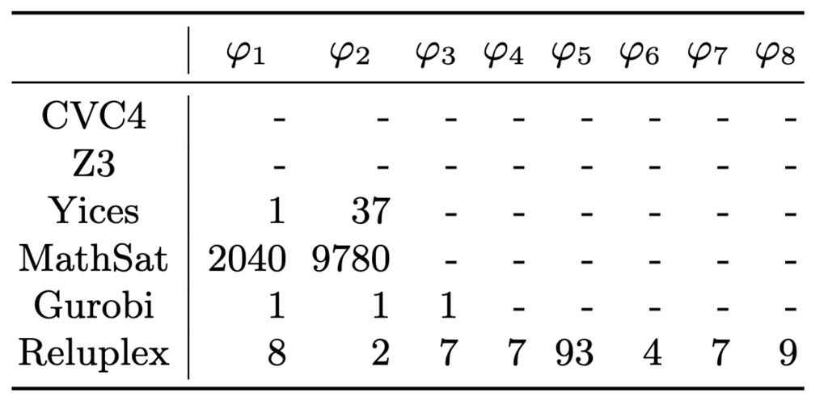

   Results of the 4 hour timeout experiment. Each entry is solution time (in seconds)

   ReLUPlex was able to verify all the properties in under 4 hours. The other solvers were able to verify atmost three of the eight properties. Gurobi was able to verify the most properties (3) however, the authors note that these properties did not require any case splits.
2. The authors ran ReLUPlex on 10 qualitative properties $\phi_1 \cdots \phi_{10}$. One of the properties is presented below:

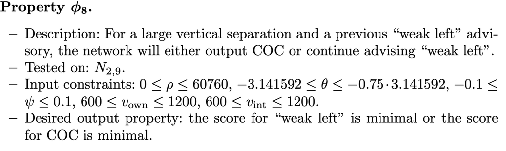

   Qualitative property 8

   The results are presented below:

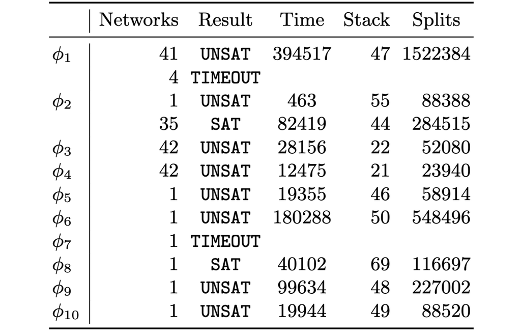

   Verifying ACAS Xu properties

   Later study of the results revealed that the properties for which ReLUPlex found counterexamples (`SAT` = inconsistency between the ReLU network and the lookup table) were actual errors in the ACAS Xu system.
3. The authors also conducted adverserial robustness tests against the ACAS Xu system. For this set of experiments, the authors queried ReLUPlex to find an adverserial data point $x^\prime$ that is $\delta$ infinity norm distance away from an input $x$ (i.e.: $|x - x^\prime|_{\infty} < \delta$) where the ACAS Xu system outputs a different advisory. The results are presented below:

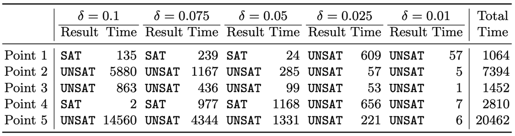

   Adverserial robustness results

   The results show that can be used to prove local robustness for a given $x$ and $\delta$. `SAT` depicts that ReLUPlex found an adverserial example while `UNSAT` depicts that no adverserial example within the bounded region exists.

## Conclusion

Overall, I believe that ReLUPlex does find a substantial application domain in which the compromises it makes give practical results. The authors demonstrate that ReLUPlex is able to verify the ACAS Xu system in a reasonable amount of time. However, the paper also demonstrates how hard it is to scale up a constraint based approach to handle the smallest of practical DNNs. Future work in this area, till today, has only managed to scale to networks with about $10^5$ nodes[7].

Furthermore, various improvements have been made to ReLU networks since the time of this paper. Presently, it is common for most feedforward networks to use `LeakyReLU` and `LayerNorm` activations interspersed with linear layers. ReLUPlex cannot handle these changes.

## Summary of Verdicts

> 🚩 **Lowering Expectations** (Sufficient Soundness):` This definition provides a concrete formalism for the notion of *sufficient* soundness. Verifying soundness for a large input range is intractable; instead, we predetermine a feasible input region and attempt to derive certifications for said region. This can be thought of as an instantiation of lowering expectations.

> 🚩 **Lowering Expectations** (Restricting to ReLU networks): ReLUPlex attempts to make a sufficiently scalable SMT verifier rescrited to the class of ReLU networks. This is a practical tradeoff because ReLU nets are popular in practice.

> ⚠️ **Pitfall**: (Give “scalability”, take away “expressiveness”) ReLUPlex attempts to make a sufficiently scalable ReLU net verifier but, in the process, it makes a number of assumptions that make it difficult to generalize to small purturbations in the architecture (eg: ReLU nets have been modified to include `LayerNorm` normallizations and `LeakyReLU` activations. ReLUPlex cannot handle these changes).

> 🚩 **Exploiting Laziness** (Using SMT solvers instead of SAT solvers): Instead of eagerly trying to solve all possible constraints, ReLUPlex exploits the structure of the problem and divides the problem of verifying ReLU nets into the problem of selecting which constraints to verify and verifying those constraints using a theory suitable for linear inequalities.

> 🚩 **Exploiting Laziness** (Lazy constraint solving in Simplex): Simplex does not eagerly try to satisfy all the constraints. Instead, it locally satisfies constraints and iteratively improves the solution until all constraints are satisfied. This is a case of making the problem easier by relaxing the search space and then iteratively improving the solution.

> 🚩 **Exploiting Shallowness** (Eager evaluation of simplex): The simplex algorithm is designed to return the best solution to a linear program. However, ReLUPlex, instead, modifies the simplex algorithm to return the first solution to a linear program. This is because we are only interested in the existence of a solution to the linear program, not the best solution.

> 🚩 **Exploiting Laziness** (Incremental Case Splitting): ReLUPlex uses incremental case splitting to reduce the number of case splits it needs to consider. Specifically, it will only consider case splits when the theory solver fails to find a satisfying assignment.

> 🚩 **Apply Magic** (Inexact Floating Point Arithmetic): ReLUPlex models linear constraints using approximations of floating point constraints. This speeds up the pivot operatins.

> ⚠️ **Pitfall**: (Magic is Unreliable) Inexact floating point arithmetic opens an attack vector to systematically invalidate the certification. This was identified and demonstrated by future work [3].

> 🚩 **Apply Magic** (Bound tightening): ReLUPlex unifies single variable linear constraints prior to calling the theory solver. This reduces the number of variables that the theory solver needs to consider and, furthermore, allows us to better inform SAT case splitting.

## References

In addition to the citations in the text, I found the following resources helpful in understanding the paper:

- I used this survey[5] to understand the different approaches to verifying neural networks and the mathematical formalism.
- This tutorial[1] was helpful in understanding the Simplex algorithm and the encoding of the ReLU network as a linear program.

[1]

Albarghouthi, A. 2021. [Introduction to neural network verification](https://arxiv.org/abs/2109.10317). *CoRR*. abs/2109.10317, (2021).

[2]

Eykholt, K. et al. 2018. [Robust physical-world attacks on deep learning visual classification](https://doi.org/10.1109/CVPR.2018.00175). *2018 IEEE conference on computer vision and pattern recognition, CVPR 2018, salt lake city, UT, USA, june 18-22, 2018* (2018), 1625–1634.

[3]

Jia, K. and Rinard, M.C. 2020. [Exploiting verified neural networks via floating point numerical error](https://arxiv.org/abs/2003.03021). *CoRR*. abs/2003.03021, (2020).

[4]

Katz, G. et al. 2017. [Reluplex: An efficient SMT solver for verifying deep neural networks](https://doi.org/10.1007/978-3-319-63387-9\_5). *Computer aided verification - 29th international conference, CAV 2017, heidelberg, germany, july 24-28, 2017, proceedings, part I* (2017), 97–117.

[5]

Li, L. et al. 2020. [SoK: Certified robustness for deep neural networks](https://arxiv.org/abs/2009.04131). *CoRR*. abs/2009.04131, (2020).

[6]

Smilkov, D. et al. 2016. [TensorFlow playground](https://playground.tensorflow.org/).

[7]

Tjeng, V. and Tedrake, R. 2017. [Verifying neural networks with mixed integer programming](http://arxiv.org/abs/1711.07356). *CoRR*. abs/1711.07356, (2017).